# Learning Diary

This learning diary is created to capture error occurred while learning R programming.

Priyal Agarwal  
23102422  
`p.agarwal4@universityofgalway.ie`

**Diary Entry Date: 10-Feb-2024**

Note that this entry is to explain the error came at the time of loading CSV in R studio and solution to the error.

When I was trying to upload a CSV in R studio , I got error as Figure 1 . No such file or directory.

[figure not shown]

Figure 1: No such file or directory

**Solution**:

It seems that CSV file is places in different path and Path setup in R is different. So checked the path of directory using getwd(). This gave the detail of current path of R, changed this path to new path using setwd(). This resolved issue and CSV got uploaded successfully.

**Diary Entry Date: 14-Feb-2024**

This diary entry is to explain the the issue I was getting while creating a histogram.

Figure 2: No color in histogram even after giving color in code.

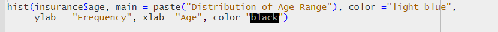

Figure 2: Color Error

I was trying to create histogram to show distribution of age using above code, but when I was doing that I was getting gray color in histogram instead of light blue color which I gave.

[figure not shown]

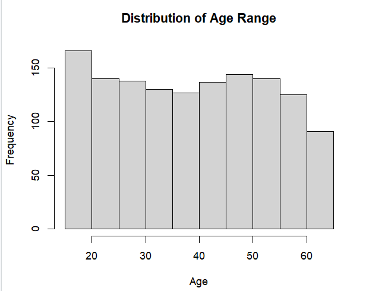

Figure 3: Colorless Histogram

**Solution**

I realized that parameter for color should be written as ‘col’ not ‘color’ after checking on google.

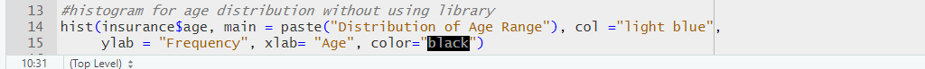

Color Solution

After changes, it worked and histogram shtarted showing correct color.

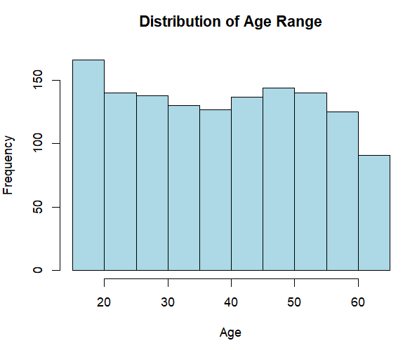

Figure 4: Colorful Histogram

In my code I had two *col* one for chart and other for border, I wanted to try if I reverse the code and make ‘color’ as ‘col’ and ‘col’ to ‘color’, what will be the effect of that on my chart. Here is the modified code:

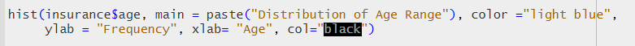

Figure 5: New experimental code

When I interchanged it, as ‘color’ doesn’t give any *Color* so it made the chart colorless and ‘col’ make it totally black. So in case We need to use two colors in the chart like in our case, one for chart and other for border. It’s better to use *col= chart color* for chart color and **border= border color* eliminated confusion and give correct color in chart and border.

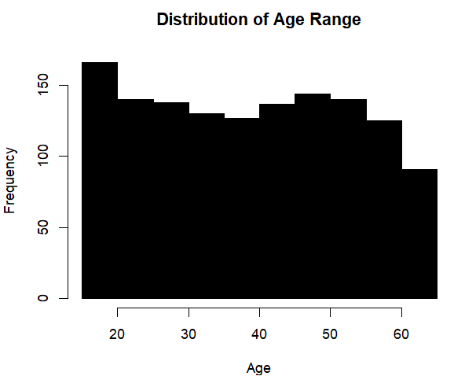

Figure 6: New code Histogram

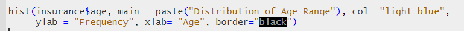

Figure 7: Correct code

**Diary Entry Date:26-Mar-2024**

[figure not shown]

Filter Error